# transportation analysis2

## 前序

延續作業1的主題「民眾大眾交通搭乘分析」，已找到從原始資料萃取出我想要的資料(newdata.csv)，想透過這個資料觀察是否「年齡」對於「大眾運輸搭乘率」會不會有影響。

另外因為資料是調查抽樣資料，抽樣人數各縣市不一，故以百分比的方式呈現「大眾運輸搭乘率」。

## code

1.匯入需要的library

```r
library(dplyr)
library(magrittr)
```

```r
library(ggplot2)
```

2.匯入前一份作業已收集的資料

```r
#load the data
newdata2<-read.csv('C:\\Users\\user\\Desktop\\newdata2.csv',sep=",")
head(newdata2,5)
```

```
##       age    sex location             transportation education job
## 1 above65 female   台南市 自用小客車(含小客貨兩用車)  小學以下   1
## 2 above65   male   台中市                       機車      專科  10
## 3   40-50 female   台北市                       機車      大學   7
## 4 above65   male   基隆市                   市區公車      專科  10
## 5 above65 female   雲林縣                       機車  小學以下   1
```

- 先將年齡分成三個階層，15到20歲、20到60歲以及60歲以上。15到20歲為青年人，20到60歲為壯年人，60歲以上則為老人，以各年齡層來說，計算每個縣市的使用大眾運輸百分率。

3.設計兩個function，一個為找到特定年齡搭乘大眾運輸的資料，另一個是計算特定年齡搭乘大眾運輸除以該年齡層之人數的比率

```r
#get certain part of data (15-20,20-60,60UP)
levels(newdata2$transportation)
```

```
##  [1] "不知道/拒答"                "公路客運"
##  [3] "市區公車"                   "交通車"
##  [5] "自用大客車"                 "自用大貨車(含大客貨兩用車)"
##  [7] "自用小客車(含小客貨兩用車)" "自用小貨車"
##  [9] "自行車"                     "免費公車"
## [11] "步行"                       "計程車(含共乘)"
## [13] "飛機"                       "高鐵"
## [15] "國道客運"                   "捷運"
## [17] "渡輪"                       "臺鐵"
## [19] "機車"
```

```r
certaindata<-function(data,expression){
  certain<-data%>%
    dplyr::select(sex,age,location,transportation)%>%
    filter(expression&(as.integer(newdata2$transportation)%in%c(2,3,4,10,14,15,16,18)))
  certain
}
#get the rate about whether people commute by public transportation
getrate<-function(data,data2,expression){
  total<-data%>%
    dplyr::select(sex,age,location,transportation)%>%
    filter(expression)
  h1<-count(total,location)
  h2<-count(data2,location)
  rate<-data.frame(h1[1],h2[2]/h1[2])
  names(rate)<-c('location','rate')
  rate
}
```

4.套用function,算出各縣市的大眾搭乘率，並且畫成長條圖，方便觀察。

- 第一張為「15-20歲年齡的民眾搭乘大眾運輸率」

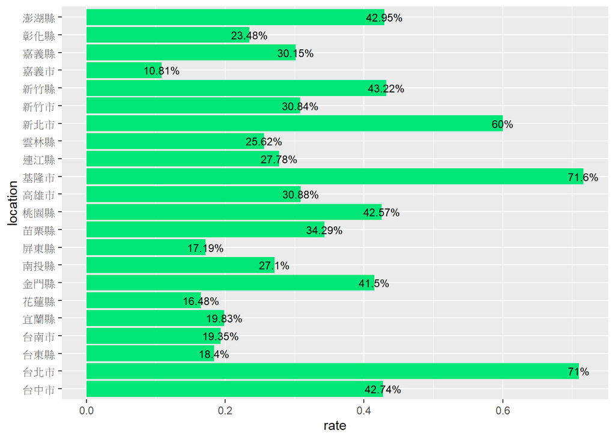

```r
#filter people who ages between 15-20 and between 20-60 and above 60
#age between 15 and 20
expression1<-newdata2$age=='15-18'|newdata2$age=='18-20'
youngadult<-certaindata(newdata2,expression1)
p1<-getrate(newdata2,youngadult,expression1)
ggplot(p1,aes(x=location,y=rate))+
  geom_bar(stat = 'identity',fill='#00e677')+
  geom_text(label=paste0(round(p1$rate,4)*100,"%"),size=3.2)+
  coord_flip()
```

*第二張為「20-60歲年齡的民眾搭乘大眾運輸率」

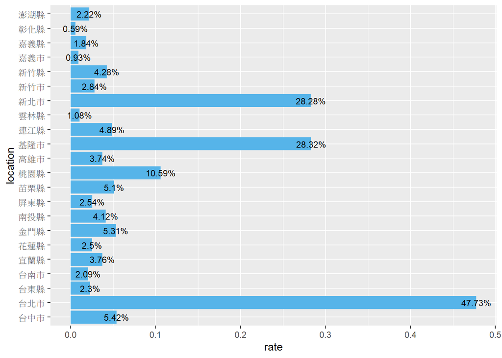

```r
#age between 20 and 60
expression2<-as.integer(newdata2$age)>=3&as.integer(newdata2$age)<=6
adult<-certaindata(newdata2,expression2)
p2<-getrate(newdata2,adult,expression2)
ggplot(p2,aes(x=location,y=rate))+
  geom_bar(stat = 'identity',fill='#56B4E9')+
  geom_text(label=paste0(round(p2$rate,4)*100,"%"),size=3.2)+
  coord_flip()
```

*第三張為「60歲以上年齡的民眾搭乘大眾運輸率」

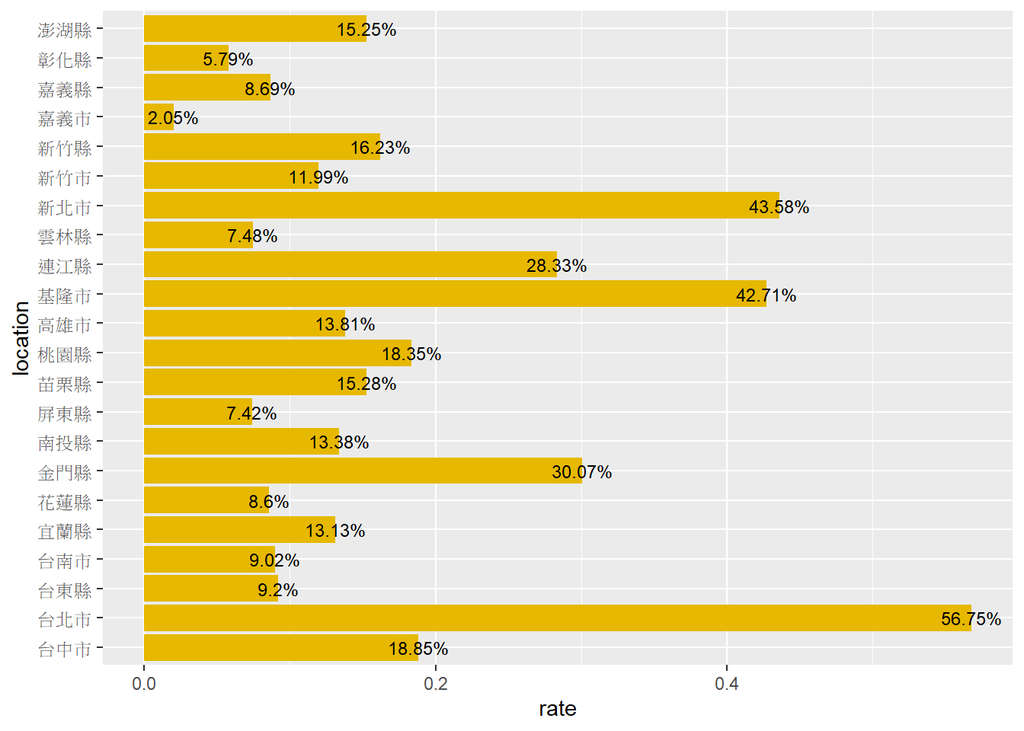

```r
#age above 60
expression3<-newdata2$age=='60-65'|newdata2$age=='above65'
elder<-certaindata(newdata2,expression3)
p3<-getrate(newdata2,elder,expression3)
ggplot(p3,aes(x=location,y=rate))+
  geom_bar(stat = 'identity',fill='#e6b800')+
  geom_text(label=paste0(round(p3$rate,4)*100,"%"),size=3.2)+
  coord_flip()
```

5.全台灣各縣市大眾運輸使用率區域分配圖(不分年齡)

```r
#set up the libraries which i need
library(GISTools)
library(rgdal)
```

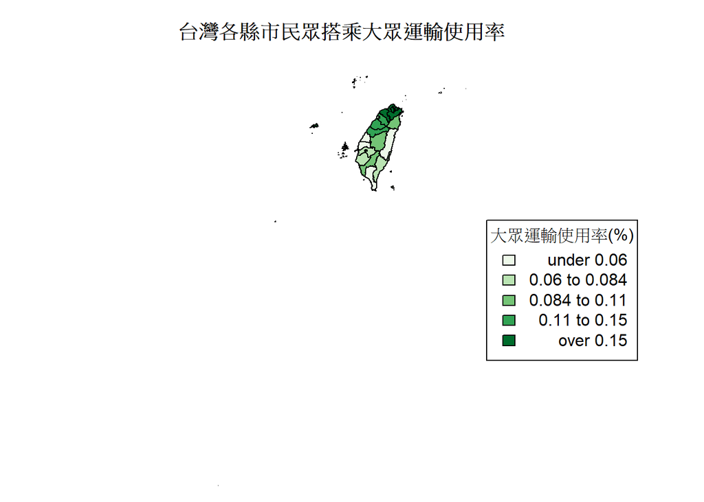

```r
library(sp)
library(dplyr)

#get the data and map
setwd('C:/Users/user/Desktop/test')
TW <- readOGR(dsn = ".", layer = "COUNTY_MOI_1080617",use_iconv = TRUE, encoding="UTF-8")
map<-TW@data
rate<-read.csv('C:\\Users\\user\\Desktop\\alldata.csv')

#combine two data
rate2<-rate
rate2$location<-as.character(rate2$location)
rate2$location<-c('New Taipei City','Yilan County','Taoyuan City','Hsinchu County',
                  'Miaoli County','Taichung City','Changhua County','Nantou County',
                  'Yunlin County','Chiayi County','Tainan City','Kaohsiung City',
                  'Pingtung County','Taitung County','Hualien County','Penghu County',
                  'Keelung City','Hsinchu City','Chiayi City','Taipei City',
                  'Kinmen County','Lienchiang County')
order_map <- map[ order(map$COUNTYENG), ]
order_rate<-rate2[order(rate2$location),]
order_map$avg_R<-order_rate$n
order_map<-order_map[order(as.numeric(rownames(order_map))),,drop=FALSE]

# plot
par(mar = c(0,0,3,1))
shades <- auto.shading(order_map$avg_R, cutter = quantileCuts,n =5, cols = brewer.pal(5, "Greens"))
choropleth(TW, order_map$avg_R, shading=shades,cex=4)
title('台灣各縣市民眾搭乘大眾運輸使用率')
choro.legend(125.4193,20.76209, shades,title='大眾運輸使用率(%)')
```

## 結論

從「台灣各縣市民眾搭乘大眾運輸使用率」這張圖中，可以發現「北部」縣市的民眾較常使用大眾運輸可能是因為大眾運輸系統較完善，而南部的民眾就不太習慣使用大眾運輸系統。